# CCobb_Livesession4assignment

Che’ Cobb

September 18, 2018

```r
library(rvest)
```

```r
library(xml2)
library(tidyr)
library(ggplot2)
```

## 1.Harry Potter Cast (50%)

- **a. In the IMDB, there are listings of full cast members for movies. Navigate to http://www.imdb.com/title/tt1201607/fullcredits?ref_=tt_ql_1. Feel free to View Source to get a good idea of what the page looks like in code.**
- **b. Scrape the page with any R package that makes things easy for you. Of particular interest is the table of the Cast in order of crediting. Please scrape this table (you might have to fish it out of several of the tables from the page) and make it a data.frame() of the Cast in your R environment**

```r
#Reading the HTML code from the website and put  into html_table(cast)
url <- "https://www.imdb.com/title/tt1201607/fullcredits?ref_=tt_ql_1"
movie_webpage <- read_html(url)
cast<-html_table(html_nodes(movie_webpage, 'table'))

#put 3rd node which is the cast in to data.frame(test)
test<-data.frame(cast[3])
head(test)
```

```
##   X1               X2  X3                         X4
## 1
## 2       Ralph Fiennes ...             Lord Voldemort
## 3      Michael Gambon ... Professor Albus Dumbledore
## 4        Alan Rickman ...    Professor Severus Snape
## 5    Daniel Radcliffe ...               Harry Potter
## 6        Rupert Grint ...                Ron Weasley
```

### c. Clean up the table

- **It should not have blank observations or rows, a row that should be column names, or just ‘.’**
- **It should have intuitive column names (ideally 2 to start - Actor and Character)**
- **In the film, Mr. Warwick plays two characters, which makes his row look a little weird. Please replace his character column with just “Griphook / Professor Filius Flitwick” to make it look better.**
- **One row might result in “Rest of cast listed alphabetically” - remove this observation.**

```r
#delete first row and copy X2 and X4
Cast_1 <-test[-1,c(-1, -3)]
#rename X2 as Actor and X4 as Character
names(Cast_1) <- c("Actor", "Character")
#Clean the second column
Cast_1$Character<-gsub('\n  ','',Cast_1$Character)
Cast_1=Cast_1[!grepl('alphabetically:', Cast_1$Character),]
head(Cast_1)
```

```
##              Actor                  Character
## 2    Ralph Fiennes             Lord Voldemort
## 3   Michael Gambon Professor Albus Dumbledore
## 4     Alan Rickman    Professor Severus Snape
## 5 Daniel Radcliffe               Harry Potter
## 6     Rupert Grint                Ron Weasley
## 7      Emma Watson           Hermione Granger
```

```r
#Lets find the line with Mr. Warwick
grep("Warwick", Cast_1$Actor)
```

```
## [1] 10
```

```r
print(Cast_1[10,])
```

```
##            Actor                                       Character
## 11 Warwick Davis Griphook /            Professor Filius Flitwick
```

```r
Cast_1[10,] <- c("Warwick Davis", "Griphook / Professor Filius Flitwick")
print(Cast_1[10,])
```

```
##            Actor                            Character
## 11 Warwick Davis Griphook / Professor Filius Flitwick
```

```r
#check if Rest of cast listed alphabetically is in Cast_1
grep("Rest of cast listed alphabetically", Cast_1$Actor)
```

```
## integer(0)
```

```r
grep("Rest of cast listed alphabetically", Cast_1$Character)
```

```
## integer(0)
```

### d.

- **Split the Actor’s name into two columns: FirstName and Surname. Keep in mind that some actors/actresses have middle names as well. Please make sure that the middle names are in the FirstName column, in addition to the first name (example: given the Actor Frank Jeffrey Stevenson, the FirstName column would say “Frank Jeffrey.”)**

### e.

- **Present the first 10 rows of the data.frame() - It should have only FirstName, Surname, and Character columns**

```r
Cast_2 <- extract(Cast_1, Actor, c("FirstName", "Surname"), "([^ ].+) (.*)")
head(Cast_2,10)
```

```
##    FirstName   Surname                            Character
## 2      Ralph   Fiennes                       Lord Voldemort
## 3    Michael    Gambon           Professor Albus Dumbledore
## 4       Alan   Rickman              Professor Severus Snape
## 5     Daniel Radcliffe                         Harry Potter
## 6     Rupert     Grint                          Ron Weasley
## 7       Emma    Watson                     Hermione Granger
## 8     Evanna     Lynch                        Luna Lovegood
## 9   Domhnall   Gleeson                         Bill Weasley
## 10  Clémence     Poésy                       Fleur Delacour
## 11   Warwick     Davis Griphook / Professor Filius Flitwick
```

### 2. SportsBall (50%)

- **a. On the ESPN website, there are statistics of each NBA player. Navigate to the San Antonio Spurs current statistics (likely http://www.espn.com/nba/team/stats/_/name/sa/san-antonio-spurs). You are interested in the Shooting Statistics table**
- **b. Scrape the page with any R package that makes things easy for you. There are a few tables on the page, so make sure you are targeting specifically the Shooting Statistics table**

```r
url <- "http://www.espn.com/nba/team/stats/_/name/sa/san-antonio-spurs"
#Reading the HTML code from the website
spurs <- read_html(url)
spurs_table<-html_table(fill=TRUE, html_nodes(spurs, 'table'))
# It appears the third 'node' is what I am after looking at the html page.
shooting_table<-data.frame(spurs_table[2])
head(shooting_table)
```

```
##                      X1                  X2                  X3
## 1   SHOOTING STATISTICS SHOOTING STATISTICS SHOOTING STATISTICS
## 2                PLAYER                 FGM                 FGA
## 3 LaMarcus Aldridge, PF                 7.4                16.0
## 4       Patty Mills, PG                 5.0                11.4
## 5          Rudy Gay, SF                 5.2                13.0
## 6      Manu Ginobili, G                 3.0                 7.4
##                    X4                  X5                  X6
## 1 SHOOTING STATISTICS SHOOTING STATISTICS SHOOTING STATISTICS
## 2                 FG%                 3PM                 3PA
## 3                .463                 0.6                 1.0
## 4                .439                 2.6                 7.0
## 5                .400                 0.8                 3.6
## 6                .405                 1.2                 3.6
##                    X7                  X8                  X9
```

[output cut: 20 more lines]

### c. Clean up the table (You might get some warnings if you’re working with tibbles)

- **You’ll want to create an R data.frame() with one observation for each player. Make sure that you do not accidentally include blank rows, a row of column names, or the Totals row in the table as observations.**
- **The column PLAYER has two variables of interest in it: the player’s name and their position, denoted by 1-2 letters after their name. Split the cells into two columns, one with Name and the other Position.**
- **Check the data type of all columns. Convert relevant columns to numeric. Check the data type of all columns again to confirm that they have changed!**

```r
Shooting <- data.frame(shooting_table)
#rename the headers and  delete 1st, 2nd and the last lines
names(Shooting) <- Shooting[2,]
Shooting <- Shooting[c(-1,-2,-20),]
head(Shooting)
```

```
##                  PLAYER FGM  FGA  FG% 3PM 3PA  3P% FTM FTA  FT% 2PM  2PA
## 3 LaMarcus Aldridge, PF 7.4 16.0 .463 0.6 1.0 .600 8.2 8.4 0.98 6.8 15.0
## 4       Patty Mills, PG 5.0 11.4 .439 2.6 7.0 .371 0.8 1.0 0.80 2.4  4.4
## 5          Rudy Gay, SF 5.2 13.0 .400 0.8 3.6 .222 1.0 1.8 0.56 4.4  9.4
## 6      Manu Ginobili, G 3.0  7.4 .405 1.2 3.6 .333 1.8 2.2 0.82 1.8  3.8
## 7   Dejounte Murray, PG 2.8  6.2 .452 0.8 1.2 .667 1.4 1.8 0.78 2.0  5.0
## 8       Tony Parker, PG 2.8  7.4 .378 0.0 1.0 .000 1.0 1.4 0.71 2.8  6.4
##    2P%   PPS AFG%
## 3 .453 1.475 0.48
## 4 .545 1.175 0.55
## 5 .468  .938 0.43
## 6 .474 1.216 0.49
## 7 .400 1.258 0.52
## 8 .438  .892 0.38
```

```r
Shooting_1 <-separate(data=Shooting, col=PLAYER, into=c("Name","Position"), sep = "\\,")
head(Shooting_1)
```

```
##                Name Position FGM  FGA  FG% 3PM 3PA  3P% FTM FTA  FT% 2PM
## 3 LaMarcus Aldridge       PF 7.4 16.0 .463 0.6 1.0 .600 8.2 8.4 0.98 6.8
## 4       Patty Mills       PG 5.0 11.4 .439 2.6 7.0 .371 0.8 1.0 0.80 2.4
## 5          Rudy Gay       SF 5.2 13.0 .400 0.8 3.6 .222 1.0 1.8 0.56 4.4
## 6     Manu Ginobili        G 3.0  7.4 .405 1.2 3.6 .333 1.8 2.2 0.82 1.8
## 7   Dejounte Murray       PG 2.8  6.2 .452 0.8 1.2 .667 1.4 1.8 0.78 2.0
## 8       Tony Parker       PG 2.8  7.4 .378 0.0 1.0 .000 1.0 1.4 0.71 2.8
##    2PA  2P%   PPS AFG%
## 3 15.0 .453 1.475 0.48
## 4  4.4 .545 1.175 0.55
## 5  9.4 .468  .938 0.43
## 6  3.8 .474 1.216 0.49
## 7  5.0 .400 1.258 0.52
## 8  6.4 .438  .892 0.38
```

```r
str(Shooting_1)
```

```
## 'data.frame':    15 obs. of  16 variables:
##  $ Name    : chr  "LaMarcus Aldridge" "Patty Mills" "Rudy Gay" "Manu Ginobili" ...
##  $ Position: chr  " PF" " PG" " SF" " G" ...
##  $ FGM     : chr  "7.4" "5.0" "5.2" "3.0" ...
##  $ FGA     : chr  "16.0" "11.4" "13.0" "7.4" ...
##  $ FG%     : chr  ".463" ".439" ".400" ".405" ...
##  $ 3PM     : chr  "0.6" "2.6" "0.8" "1.2" ...
##  $ 3PA     : chr  "1.0" "7.0" "3.6" "3.6" ...
##  $ 3P%     : chr  ".600" ".371" ".222" ".333" ...
##  $ FTM     : chr  "8.2" "0.8" "1.0" "1.8" ...
##  $ FTA     : chr  "8.4" "1.0" "1.8" "2.2" ...
##  $ FT%     : chr  "0.98" "0.80" "0.56" "0.82" ...
##  $ 2PM     : chr  "6.8" "2.4" "4.4" "1.8" ...
##  $ 2PA     : chr  "15.0" "4.4" "9.4" "3.8" ...
##  $ 2P%     : chr  ".453" ".545" ".468" ".474" ...
##  $ PPS     : chr  "1.475" "1.175" ".938" "1.216" ...
##  $ AFG%    : chr  "0.48" "0.55" "0.43" "0.49" ...
```

```r
Shooting_1[, c(3:14)] <- sapply(Shooting_1[, c(3:14)], as.numeric, suppressWarnings(as.numeric(c("1", "2", "X"))))
sapply(Shooting_1, class)
```

```
##        Name    Position         FGM         FGA         FG%         3PM
## "character" "character"   "numeric"   "numeric"   "numeric"   "numeric"
##         3PA         3P%         FTM         FTA         FT%         2PM
##   "numeric"   "numeric"   "numeric"   "numeric"   "numeric"   "numeric"
##         2PA         2P%         PPS        AFG%
##   "numeric"   "numeric" "character" "character"
```

### d. Create a colorful bar chart that shows the Field Goals Percentage Per Game for each person. It will be graded on the following criteria.

- **Informative Title, centered**
- **Relevant x and y axis labels (not simply variables names!)**
- **Human-readable axes with no overlap (you might have to flip x and y to fix that). Note: You do not have to convert the decimal to a percentage.**
- **Color the columns by the team member’s position (so, all PF’s should have the same color, etc.)**

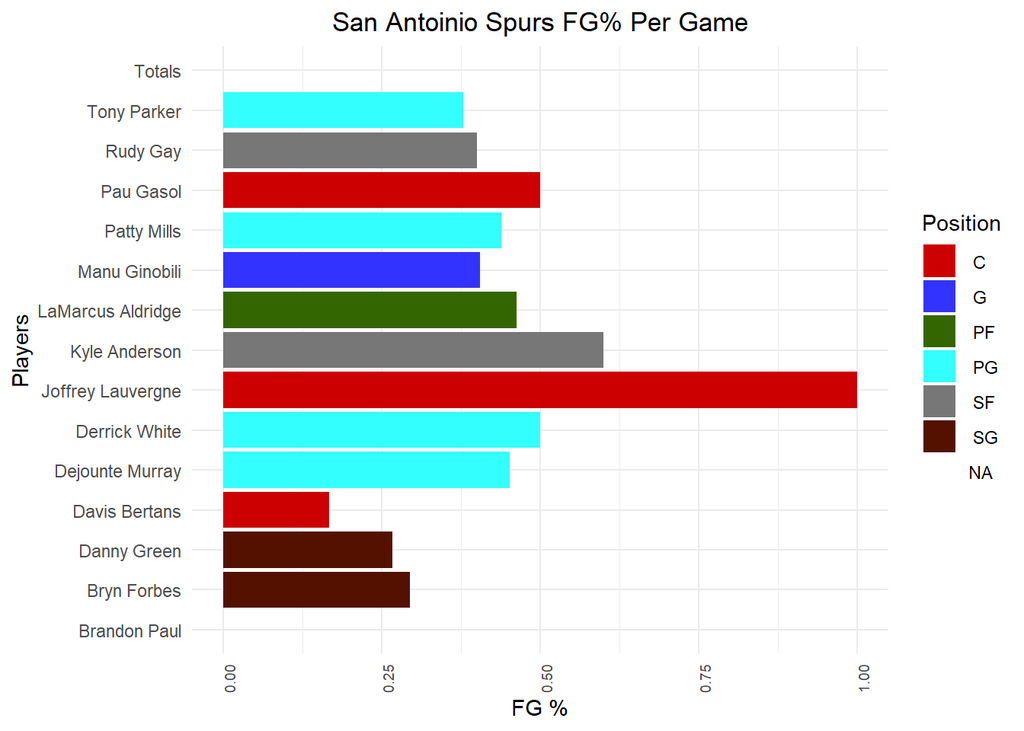

```r
ggplot(Shooting_1, aes(Name,`FG%`, fill=Position)) +
  geom_bar(stat='identity') + coord_flip()  + theme_minimal() +
  theme(axis.text.x=element_text(size=rel(0.8), angle=90)) +
  theme(plot.title = element_text(hjust = 0.5))+
  ggtitle("San Antoinio Spurs FG% Per Game") +
  labs(x="Players",y="FG %")+
  scale_fill_manual(values=c("#CC0000", "#3333FF", "#336600", "#33FFFF", "#777777", "#551100"))
```